# Capstone Project Report

Sentiment Analysis using Twitter Data

Bloomiya Kurian

## **INTRODUCTION**

Ever since President Trump signed Executive orders on Immigration and travel ban on immigrants from certain countries, people across the globe, especially in the U.S, have started debates in favor and against the move. The basis for these executive orders is national security. But some people believe that the ban is against the US culture and constitution. Others think that the move is essential in the wake of several terrorist attacks happening in the US and across the world. Many have been expressing their support and calls to protest against the President’s actions and his views through social media sites.

## **THE PROBLEM**

In this project I would like to analyze certain types of tweets posted on Twitter through Sentiment Analysis. The specific questions I would like to explore are:

## **DATA SET and SCOPE**

Tweets that contain words or hashtags such as ‘immigrationban’, ‘travelban’, ‘muslimban’, ‘BanIslam’, ‘resist’, ‘DeleteUber’, ‘IResist’ and ‘TheResistance’ were collected through Twitter Search API. The current scope is limited to tweets posted from states in the United States.

The Twitter Search API returned the following attributes:

1. Text: - This column contains the text of the tweet
2. Favorited:-“Indicates whether the Tweet has been liked by the authenticating user”
3. Favorite Count:-" Indicates approximately how many times the Tweet has been liked by Twitter users"
4. ReplyToSN:- “If the represented Tweet is a reply, this field will contain the screen name of the original Tweet’s author”
5. Created:- “UTC time when the Tweet was created”
6. Truncated:-“Indicates whether the value of the text parameter was truncated, for example, as a result of a retweet exceeding the 140 character Tweet length. Truncated text will end in ellipsis, like this … Since Twitter now rejects long Tweets vs truncating them, the large majority of Tweets will have this set to false . Note that while native retweets may have their toplevel text property shortened, the original text will be available under the retweeted_status object and the truncated parameter will be set to the value of the original status (in most cases, false ).”
7. ReplyToSID:- “If the represented Tweet is a reply, this field will contain the integer representation of the original Tweet’s ID”
8. ID: “The integer representation of the unique identifier for the Tweet. This number is greater than 53 bits and some programming languages may have difficulty/silent defects in interpreting it”
9. ReplyToUID:- “If the represented Tweet is a reply, this field will contain the integer representation of the original Tweet’s author ID”
10. StatusSource:- “Utility used to post the Tweet, as an HTML-formatted string. Tweets from the Twitter website have a source value of web”
11. ScreenName:- The user screen name
12. RetweetCount: - “Number of times the Tweet has been retweeted”
13. IsRetweet:-
14. Retweeted
15. Longitude
16. Latitude

## **DATA EXTRACTION AND PREPARATION**

### Step 1:Connect to Twitter REST API and download tweets

```r
### --- Install and load required packages

install.packages("twitteR")
install.packages("ROAuth")
library("twitteR")
library("ROAuth")

### --- create a twitter account and obtain required access credentials to connect to twitter API

api_key <- ""

api_secret <- ""

access_token <- ""

access_token_secret <- ""

### --- set-up twitter authentication using the keys

setup_twitter_oauth(api_key,api_secret,access_token,access_token_secret)

### --- extract tweets for each US state using searchTwitter function and write to a csv file. Few examples are shown here. A table with necessary details is provided below for all states. By replacing geocode and radius parameters for each city we can obtain tweets for all the locations included in the scope of this analysis.

tweets <- searchTwitter('travelban OR immigrationban OR muslimban OR #DeleteUber OR #BanIslam OR #Resist OR #IResist OR #TheResistance', n=100000, since='2017-01-27', until=NULL, lang="en", geocode='61.2876,-149.4869,400mi')

df_tweets_AK_Alaska <- twListToDF(tweets)
```

Longitude and Latitude values were null for most of the tweets.So location of each tweet was not available from the extracted data. But since the search query was based on a City and State, city and State attributes can be added to each data frame representing the location of the tweets.

```r
# For Alaska the radius included in the search query covered most of the cities. So exact city of each returned tweet is not available, hence adding City Name as 'Alaska'

df_tweets_AK_Alaska$City <- "Alaska"

df_tweets_AK_Alaska$State <- "AK"
```

The search queries were repeated for all other States. If the geographic structure of the State is not fitting within a radius, different cities within the state were included in the search with smaller radius. This step is to make sure the search radius does not cover outside the boundary of the State.

```r
tweets <- searchTwitter('travelban OR immigrationban OR muslimban OR #DeleteUber OR #BanIslam OR #Resist OR #IResist OR #TheResistance', n=100000, since='2017-01-27', until=NULL, lang="en", geocode='33.4564,-86.8019,100mi')

df_tweets_AL_Birmingham <- twListToDF(tweets)

tweets <- searchTwitter('travelban OR immigrationban OR muslimban OR #DeleteUber OR #BanIslam OR #Resist OR #IResist OR #TheResistance', n=100000, since='2017-01-27', until=NULL, lang="en", geocode='32.3569,-86.2578,100mi')

df_tweets_AL_Mongomery <- twListToDF(tweets)
```

## Step 2:Add City and State columns:

```r
df_tweets_AL_Birmingham$City <- "Birmingham"

df_tweets_AL_Birmingham$State <- "AL"

df_tweets_AL_Mongomery$City <- "Mongomery"

df_tweets_AL_Mongomery$State <- "AL"
```

## Step 3:Merge data frames for each state and remove duplicate tweets:

The search for tweets from Alabama was done in two steps. First with a 100 mile radius centering the city Birmingham and the second with 100 mile radius centering the city Mongomery. Since there can be a radius overlap between these two cities, same tweet can be included in both dataframes for the State. The goal is to combine all the data frames for a State into one dataframe and remove the duplicate tweets.

```r
# Combine data frames for Alabama

df_tweets_AL <- dplyr::bind_rows(df_tweets_AL_Birmingham, df_tweets_AL_Mongomery)

# Remove duplicate tweets

df_tweets_AL_Final <- df_tweets_AL %>% distinct(text, favorited,favoriteCount,replyToSN,created,truncated,replyToSID,id,replyToUID,statusSource,screenName,retweetCount,isRetweet,retweeted,longitude,latitude,.keep_all = TRUE)
```

Above steps were repeated for all the remaining States in the U.S.

#### E.g.1 Arkansas (AR)

```r
tweets <- searchTwitter('travelban OR immigrationban OR muslimban OR #DeleteUber OR #BanIslam OR #Resist OR #IResist OR #TheResistance', n=100000, since='2017-01-27', until=NULL, lang="en", geocode='34.2089,-91.9859,120mi')

df_tweets_AR_Conway <- twListToDF(tweets)

df_tweets_AR_Conway$City <- "Conway"

df_tweets_AR_Conway$State <- "AR"

tweets <- searchTwitter('travelban OR immigrationban OR muslimban OR #DeleteUber OR #BanIslam OR #Resist OR #IResist OR #TheResistance', n=100000, since='2017-01-27', until=NULL, lang="en", geocode='35.8358,-90.6230,20mi')

df_tweets_AR_Jonesboro <- twListToDF(tweets)

df_tweets_AR_Jonesboro$City <- "Jonesboro"

df_tweets_AR_Jonesboro$State <- "AR"

df_tweets_AR <- rbind(df_tweets_AR_Conway, df_tweets_AR_Jonesboro)

df_tweets_AR_Final <- df_tweets_AR %>% distinct(text, favorited,favoriteCount,replyToSN,created,truncated,replyToSID,id,replyToUID,statusSource,screenName,retweetCount,isRetweet,retweeted,longitude,latitude,.keep_all = TRUE)
```

#### E.g.2 Arizona (AZ)

```r
tweets <- searchTwitter('travelban OR immigrationban OR muslimban OR #DeleteUber OR #BanIslam OR #Resist OR #IResist OR #TheResistance', n=100000, since='2017-01-27', until=NULL, lang="en", geocode='33.7039,-112.1871,120mi')

df_tweets_AZ_Phoenix <- twListToDF(tweets)

df_tweets_AZ_Phoenix$City <- "Phoenix"

df_tweets_AZ_Phoenix$State <- "AZ"
```

Tweets collected from each state were merged into one file.

#### Step 4: Merge all the state level files into one csv file:

```r
# --- In the below code only dataframes for the examples included are included. Ideally dataframe for all the states need to be included to get the final dataset

df_tweets_US <- dplyr::bind_rows(df_tweets_AK_Alaska,df_tweets_AL_Final,df_tweets_AR_Final,df_tweets_AZ_Phoenix)

# --- Write to csv file

write.csv(df_tweets_US, file = "Tweets - Presidential actions 2017.csv")
```

## INITIAL DATA EXPLORATION

```r
# Load library

library(dplyr)
# Read data from CSV file

#tweets_data = readr::read_csv(file="Tweets - Presidential actions 2017.csv")

tweets_data = read.csv(file="Tweets - Presidential actions 2017.csv",row.names=NULL,header=TRUE)

# See structure of the data

#head(tweets_data)

# Summarize number of tweets collected per State

tweets_data %>% group_by(State) %>% summarise(tweet_count = n()) %>% arrange(tweet_count)
```

```
## # A tibble: 49 × 2
##     State tweet_count
##    <fctr>       <int>
## 1      DE         160
## 2      VT         310
## 3      WY         336
## 4      MT         484
## 5      RI         540
## 6      MS         749
## 7      WV         948
## 8      NH        1090
## 9      SD        1092
## 10     AR        1158
## # ... with 39 more rows
```

The state Delaware had the lowest number of tweets. And New York had the highest number. Since the count of tweets per State varies drastically the population for this data set is not even. States with metro cities usually have more people using social media than remote States. This could explain the reason for the outliers.

## DATA LIMITATIONS

There are few limitations to the dataset used in this analysis.

1. Search terms were biased towards resistence against actions and views of President Trump and his government.
2. Twitter Rest API does not return geo locations of all the tweets.Also it returns only tweets from past 6-8 days. The geo attributes are populated only if the user of the tweet opted to disclose the location of the user. 99.9% of extracted tweets didn’t have data populated for longitude and latitude attributes. Due to this limitation a manual search process based on radius around a geocode was followed to extract tweets from different states. This manual search could have resulted in an uneven data population from different states. Hence the overall sentiment calculated for the States would not represent the true opinion of the people in the States. The manual search effort also impacted timeline of tweet extraction. Tweets from all the states were not extracted at the same timeframe.
3. The state Idaho was missed out in the extraction process.

## SENTIMENT ANALYSIS

Once the data set is cleaned and explored the next step is to identify the sentiment of each tweet in the data set. Though the data set includes many attributes, only relevant attribute required for calculating sentiment is the ‘text’ column. Since the tweet text includes many irrelevant symbols and junks, each text needs to be cleaned to extract the actual tweet itself.

### Data Cleaning

Tweets were cleaned in two different ways: 1) By leaving hastags in the text 2) By removing hastags in the text.

```r
library('magrittr')
library(stringr)

clean_tweet = gsub("(RT|via)((?:\\b\\W*@\\w+)+)", "", tweets_data[,1])
clean_tweet = gsub("&amp", "", clean_tweet)
clean_tweet = gsub("@\\w+", "", clean_tweet)
clean_tweet = gsub("[[:punct:]]", "", clean_tweet)
clean_tweet = gsub("[[:digit:]]", "", clean_tweet)
clean_tweet = gsub("http\\w+", "", clean_tweet)
clean_tweet = gsub("[ \t]{2,}", "", clean_tweet)
clean_tweet = gsub("^\\s+|\\s+$", "", clean_tweet)
clean_tweet = gsub("\\\n", " ", clean_tweet)
clean_tweet <- str_replace_all(clean_tweet,"#[a-z,A-Z]*","")

tweets_data$Clean_Tweet_With_Hashtag <- clean_tweet

# Cleaning round 2 - by removing all words with hashtags

clean_tweet = gsub("(RT|via)((?:\\b\\W*@\\w+)+)", "", tweets_data[,1])
clean_tweet <- str_replace_all(clean_tweet,"#[a-z,A-Z]*","")
clean_tweet = gsub("&amp", "", clean_tweet)
clean_tweet = gsub("@\\w+", "", clean_tweet)
clean_tweet = gsub("[[:punct:]]", "", clean_tweet)
clean_tweet = gsub("[[:digit:]]", "", clean_tweet)
clean_tweet = gsub("http\\w+", "", clean_tweet)
clean_tweet = gsub("[ \t]{2,}", "", clean_tweet)
clean_tweet = gsub("^\\s+|\\s+$", "", clean_tweet)
clean_tweet = gsub("\\\n", " ", clean_tweet)

tweets_data$Clean_Tweet_Without_Hashtag <- clean_tweet
```

### Calculate Sentiment Score

```r
library(sentimentr)
library(exploratory)
tweets_data$Sentimentscore_withhashtag <- get_sentiment(tweets_data$Clean_Tweet_With_Hashtag)

tweets_data$Sentimentscore_withouthashtag <- get_sentiment(tweets_data$Clean_Tweet_Without_Hashtag)
```

## Data Exploration

```r
library(ggplot2)

tweets_data <- tweets_data %>% rename(score_1=`Sentimentscore_withhashtag`, score_2=`Sentimentscore_withouthashtag`)

# correlation analysis on two scores

tweets_data %>% select(score_1, score_2) %>% cor()
```

```
##           score_1   score_2
## score_1 1.0000000 0.8766415
## score_2 0.8766415 1.0000000
```

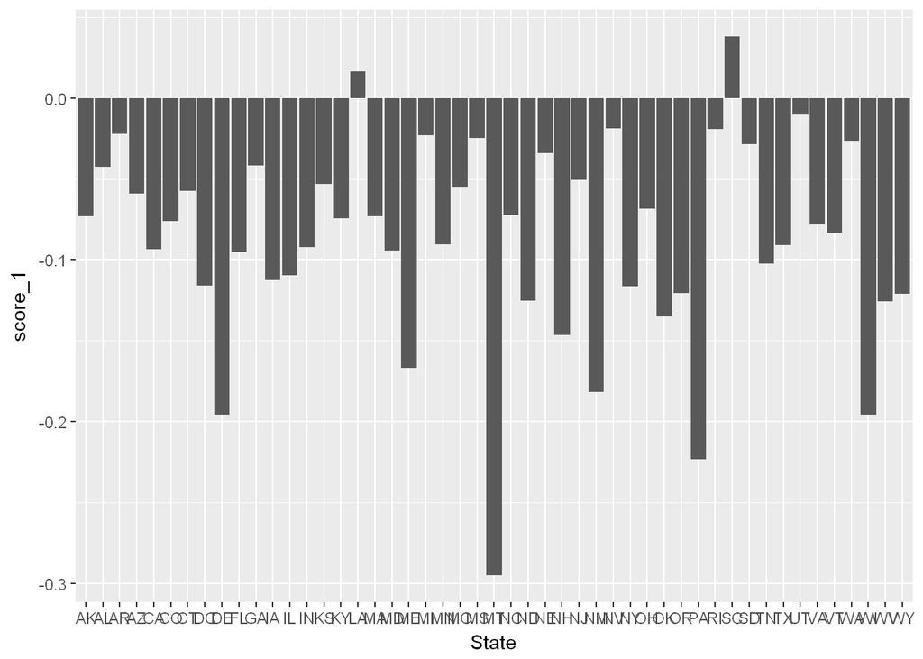

```r
# State level score distribution analysis

tweets_data %>% group_by(State) %>% summarise(score_1 = mean(score_1)) %>% ggplot(aes(State, score_1)) + geom_bar(stat='identity')
```

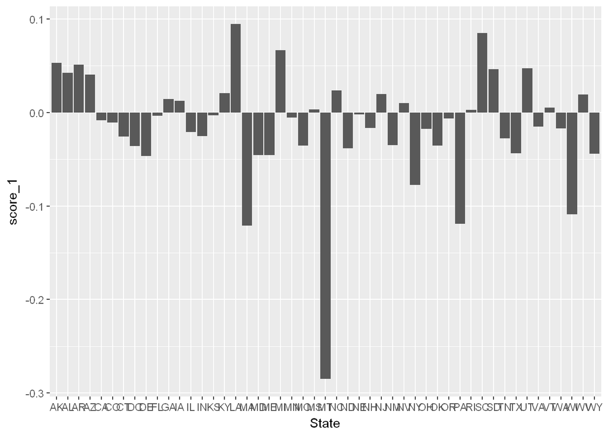

```r
tweets_data %>% group_by(State) %>% summarise(score_1 = mean(score_2)) %>% ggplot(aes(State, score_1)) + geom_bar(stat='identity')
```

A correlation analysis between the two score generated showed that the two score have a strong postive correlation. But mean sentiment score on state level showed that texts without hashtag gave more evenly distributed score. Texts with hashtag gave negative scores for all states except two.Hence scores generated by texts without hashtag were selected to perform further analysis.

### US MAP WITH SENTIMENT SCORE

The score for each state needs to be ploted on US Map so that the states can be compared against the election results map.

```r
library(ggplot2)
library(maps)

# load map data for US States

all_states <- map_data("state")

# calaculate state level sentiment score

sentiment_score <- tweets_data %>% group_by(State) %>% summarize(score_2 = mean(score_2))

# get state names for each state code

sentiment_score$State <- state.name[match(sentiment_score$State, state.abb)]

# view the dataframe

tbl_df(sentiment_score)
```

```
## # A tibble: 49 × 2
##          State      score_2
##          <chr>        <dbl>
## 1       Alaska  0.053297494
## 2      Alabama  0.042582906
## 3     Arkansas  0.051402166
## 4      Arizona  0.040667998
## 5   California -0.008232348
## 6     Colorado -0.010506056
## 7  Connecticut -0.025909477
## 8         <NA> -0.036046405
## 9     Delaware -0.046505948
## 10     Florida -0.003690799
## # ... with 39 more rows
```

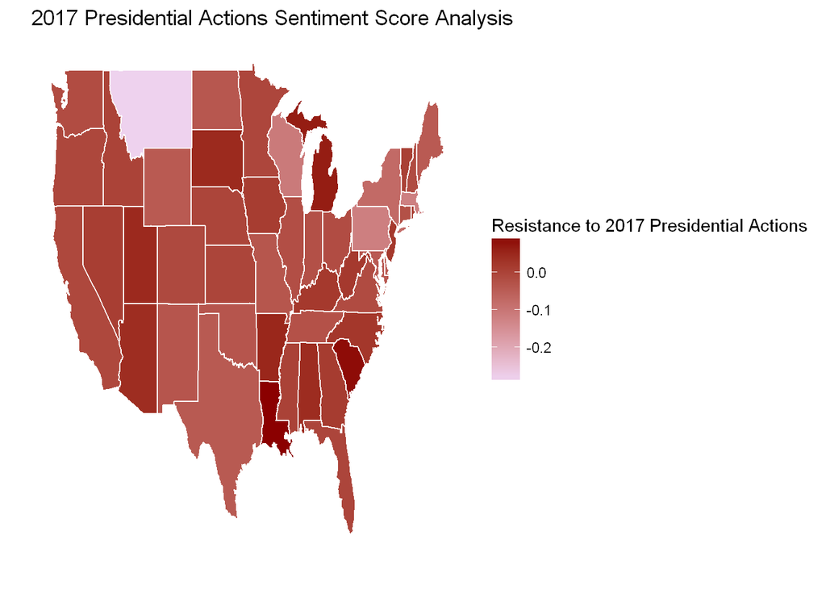

```r
# State name was not retrieved for DC. So it needs to be added seperately

sentiment_score$State[8] <- "District of Columbia"

# map_data() does not return data for Alaska. Hence it needs to be removed from sentiment_score dataframe before it is merged with map_data() results

sentiment_score <- sentiment_score[sentiment_score$State!="Alaska",]

# Since Idaho was missed in the data extraction process it needs to be added to the dataset with a neutral score

sentiment_score <- rbind(sentiment_score, c("Idaho", 0))

sentiment_score <- sentiment_score %>% mutate(score_2 = as.numeric(score_2))

sentiment_score <- sentiment_score[ order(sentiment_score$State), ]

sentiment_score_map <- sentiment_score

sentiment_score_map$State <- sapply(sentiment_score_map$State, tolower)

sentiment_score_map$region <- sentiment_score_map$State

sentiment_score_map <- merge(all_states, sentiment_score_map, by="region")

# plot the data

p <- ggplot()

p <- p + geom_polygon(data=sentiment_score_map, aes(x=long, y=lat, group = group, fill=sentiment_score_map$score_2),colour="white") + scale_fill_continuous(low = "thistle2", high = "darkred", guide="colorbar")

P1 <- p + theme_bw() + labs(fill = "Resistance to 2017 Presidential Actions", title = "2017 Presidential Actions Sentiment Score Analysis", x="", y="")

P1 + scale_y_continuous(breaks=c()) + scale_x_continuous(breaks=c()) + theme(panel.border = element_blank())
```

## STATISTICAL ANALYSIS

Regression analysis on sentiment score for each state and popular vote election results for each state will help explain if there is a relation between a state’s people’s voting trend and their sentiment towards the president’s actions post election. Trump’s Victory Margin for each state was taken for the analysis.

```r
# read popular vote election dataset

ElectionResults_data = readr::read_csv(file="2016 National Popular Vote Tracker.csv")
#ElectionResults_data <- ElectionResults_data %>% mutate(VictoryMargin = as.numeric(VictoryMargin)) - assigned NA values to VictoryMargin

ElectionResults_data[,9] <- as.numeric(sub("%","",ElectionResults_data[[9]], fixed = TRUE))

RegressionAnalysis_data <- merge(sentiment_score, ElectionResults_data, by="State")

# perform regression analysis

summary(lm(formula = score_2 ~ VictoryMargin, data=RegressionAnalysis_data))
```

```
##
## Call:
## lm(formula = score_2 ~ VictoryMargin, data = RegressionAnalysis_data)
##
## Residuals:
##       Min        1Q    Median        3Q       Max
## -0.276881 -0.021635  0.005429  0.027493  0.102923
##
## Coefficients:
##                 Estimate Std. Error t value Pr(>|t|)
## (Intercept)   -0.0162713  0.0086467  -1.882   0.0661 .
## VictoryMargin  0.0004025  0.0003630   1.109   0.2731
## ---
## Signif. codes:  0 '***' 0.001 '**' 0.01 '*' 0.05 '.' 0.1 ' ' 1
##
## Residual standard error: 0.05959 on 47 degrees of freedom
## Multiple R-squared:  0.0255, Adjusted R-squared:  0.004762
## F-statistic:  1.23 on 1 and 47 DF,  p-value: 0.2731
```

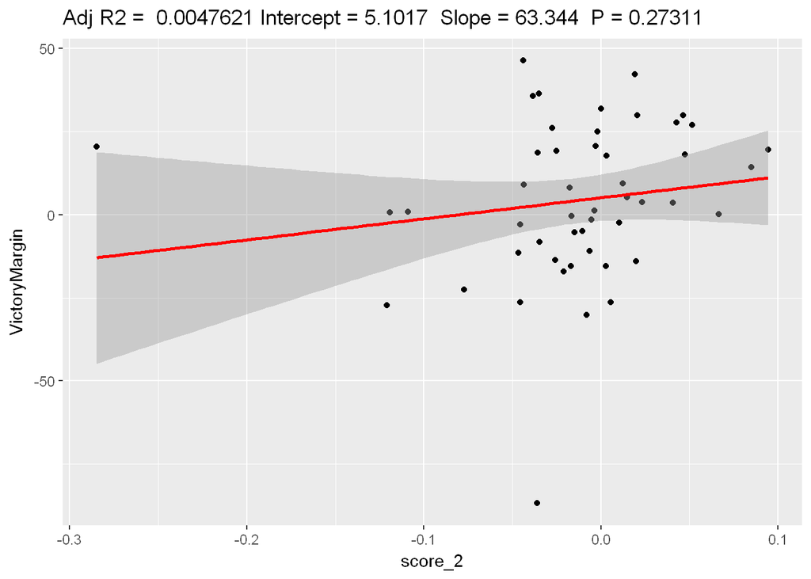

```r
# plot regression analysis results

ggplotRegression <- function (fit) {

require(ggplot2)

ggplot(fit$model, aes_string(x = names(fit$model)[2], y = names(fit$model)[1])) +
  geom_point() +
  stat_smooth(method = "lm", col = "red") +
  labs(title = paste("Adj R2 = ",signif(summary(fit)$adj.r.squared, 5),
                     "Intercept =",signif(fit$coef[[1]],5 ),
                     " Slope =",signif(fit$coef[[2]], 5),
                     " P =",signif(summary(fit)$coef[2,4], 5)))
}

ggplotRegression(lm(VictoryMargin ~ score_2, data = RegressionAnalysis_data))
```